# Analyze text data for part II of basal attributes article

Author

Julius Fenn

# 1 global variables

# 2 Notes

# 3 load data files

```r
# sets the directory of location of this script as the current directory
# setwd(dirname(rstudioapi::getSourceEditorContext()$path))

### load packages
require(pacman)
p_load('tidyverse', 'jsonlite', 'magrittr', 'xlsx',
       'stargazer', 'psych', 'jtools', 'DT', 'ggstatsplot',
       'lavaan',
       'regsem', 'MplusAutomation', 'igraph', 'ggplot2', 'tidyLPA', 'MultilayerExtraction',
       'Matrix', 'igraph', 'foreach', 'doParallel',
       'tm', 'topicmodels', 'RColorBrewer', 'wordcloud')


setwd("outputs/01_dataPreperation/final")
### load questionnaire
questionnaire <- readRDS(file = "questionnaire.rds")

CAMfiles <- readRDS(file = "CAMfiles.rds")

CAMdrawn <- readRDS(file = "CAMdrawn.rds")

CAMaggregated <- readRDS(file = "CAMaggregated.rds")

networkIndicators <- readRDS(file = "networkIndicators.rds")

CAMwordlist <- xlsx::read.xlsx2(file = "CAMwordlist.xlsx", sheetIndex = 1)
CAMwordlist$mean_valence <- as.numeric(CAMwordlist$mean_valence)
CAMwordlist$mean_degree <- as.numeric(CAMwordlist$mean_degree)

### load functions
# print(getwd())
setwd("../../../functions")
for(i in 1:length(dir())){
  # print(dir()[i])
  source(dir()[i], encoding = "utf-8")
}


setwd("../functions_CAMapp")
for(i in 1:length(dir())){
  # print(dir()[i])
  source(dir()[i], encoding = "utf-8")
}
rm(i)



### summary function
data_summary <- function(data, varname, groupnames){
  require(plyr)
  summary_func <- function(x, col){
    c(mean = mean(x[[col]], na.rm=TRUE),
      se = sd(x[[col]], na.rm=TRUE) / sqrt(length(x[[col]])))
  }
  data_sum<-ddply(data, groupnames, .fun=summary_func,
                  varname)
  data_sum <- plyr::rename(data_sum, c("mean" = varname))
  return(data_sum)
}
```

# 4 Open text answers

## 4.1 Material system that has been thought of

Question: Bitte beschreiben Sie an an welches Materialsystem oder welche Materialsysteme Sie dabei gedacht haben.

```r
DT::datatable(questionnaire[,c("PROLIFIC_PID", "openQuestion_MaterialSystem")], options = list(pageLength = 5))
```

|  | PROLIFIC_PID | openQuestion_MaterialSystem |
| --- | --- | --- |
| 2 | 74a68139f47c12e308707879cc04ea66490e6065b8dfe8b66779afec5325d63d | an autonome Rettungsmaschinen oder Roboter zum Einsatz in Kriegs- oder Katastrophengebieten, die z.B. aufgrund von Dehnbarkeit in Engstellen vordringen können |
| 3 | 40889123aede55f7b53e4bfb2a46fe17895930e0a57a3cf979d5cc2cca233d40 | Solarzell |
| 5 | 1773928d64c86ff64d4610e62c96a8cce54e7dd00b8b68656de16848766d5aaa | Materialien, die auf nachwachsenden Rohstoffen basieren. |
| 6 | 66ab847648c84da26f69f4f5b2f7373a2ae87dc487a63e37e75b216421c751c4 | Ich habe an kein bestimmtes Materialsystem gedacht. |
| 7 | b13bbac8b086f98cd9ed9c97d9e7a2fc9091563bfba9aa78026a0c446ff4e92b | Es fiel mir am Anfang etwas schwer mir was vorzustellen was es so noch nicht gibt. Aber ich habe dann richtung Robotik viel gedacht wie es dort in Zukunft ablaufen könnte |
| 8 | 46861bf8e9008ca1313b0bbc49bb3bf3ca7c1db63be4e9ef0b44f146947231df | Neue Stoffe zur konstruktion |
| 9 | 59994ec69b61ffdb4c4d881a3d7b15d65bdd82d89b5a78a529efb89ba85ebe8a | An Materialien die zukünftig verschiedene Einsatzgebiete abdecken können. Ein bestimmtes Material hatte ich dabei nicht im Kopf |
| 10 | 56a74a9c9ca121ccf8ec0d68cd4613e057fb3fff6e223d64eb3f0a08f1c26fa3 | Beim erstellen der Mind-Map habe ich versucht mir kein genaues Materialsystem vorzustellen, um die Mind-Map, möglichst objektiv und generisch zu erstellen. |
| 11 | ca729f9843a69140387d5054360a70903ac203067e2f70f7d2c77eaabfce01eb | Ich habe an Materialien gedacht, welche ihre Inspiration in der Natur finden, bspw. wasserabweisende Materialien mittels Lotuseffekt. |
| 13 | d45a20bd7dd91e466b16ce114b51bf00ed575383bf701fe33d6d705e280f9b1d | ich war mir nicht sicher, also habe ich es möglichst generell gehalten. |

[output cut: 159 more lines]

## 4.2 basal attributes: most pos. / neg.

Question: Welche drei Begriffen nehmen Sie am positivsten bzw. negativsten für die Beschreibung neuer Materialsysteme wahr?

```r
## most positive
tmp <- str_trim(unlist(str_split(string = questionnaire$multiplePositive, pattern = "\\\\")))
sort(table(tmp))
```

```
tmp
 aktive Formänderung durch Umwelteinwirkung
                                          1
                         enthält Kunststoff
                                          1
                              lebensähnlich
                                          1
passive Formänderung durch Umwelteinwirkung
                                          1
                             reaktionsfähig
                                          1
                              technologisch
                                          3
                                    autonom
                                          7
                              bioinspiriert
                                          9
                         Energie speichernd
                                          9
                        Energie generierend
                                         12
                              selbstheilend
                                         12
                           widerstandsfähig
                                         12
                             energieautonom
                                         14
                          selbstreparierend
                                         14
                            multifunktional
                                         18
                                     robust
                                         18
                                intelligent
                                         26
                               wartungsfrei
                                         26
                           energieeffizient
                                         30
                                zuverlässig
                                         30
                                  langlebig
                                         36
                                    haltbar
                                         39
                                 nachhaltig
                                         48
                                 ökologisch
                                         48
                           umweltfreundlich
                                         91
```

```r
## most negative
tmp <- str_trim(unlist(str_split(string = questionnaire$multipleNegative, pattern = "\\\\")))
sort(table(tmp))
```

```
tmp
                                    bioinspiriert
                                                1
                              Energie generierend
                                                1
                                          haltbar
                                                1
                                        langlebig
                                                1
                                       nachhaltig
                                                1
                                   reaktionsfähig
                                                1
                                           robust
                                                1
                                 widerstandsfähig
                                                1
                                      zuverlässig
                                                1
                                          autonom
                                                2
                                     wartungsfrei
                                                2
                                    lebensähnlich
                                                3
                                 umweltfreundlich
                                                3
       aktive Formänderung durch Umwelteinwirkung
                                                4
 aktive Verhaltensänderung durch Umwelteinwirkung
                                                5
                                   elektronikfrei
                                                5
      passive Formänderung durch Umwelteinwirkung
                                               13
passive Verhaltensänderung durch Umwelteinwirkung
                                               14
                                 Insekten ähnlich
                                               18
                               enthält Kunststoff
                                               66
                                leicht zerstörbar
                                              107
                                 wartungsintensiv
                                              117
                                  umweltschädlich
                                              139
```

```r
## answers of participants
DT::datatable(questionnaire[,c("PROLIFIC_PID", "multiplePositive", "multipleNegative")], options = list(pageLength = 5))
```

|  | PROLIFIC_PID | multiplePositive | multipleNegative |
| --- | --- | --- | --- |
| 2 | 74a68139f47c12e308707879cc04ea66490e6065b8dfe8b66779afec5325d63d | wartungsfrei \ widerstandsfähig \ selbstreparierend | umweltschädlich \ enthält Kunststoff \ wartungsintensiv |
| 3 | 40889123aede55f7b53e4bfb2a46fe17895930e0a57a3cf979d5cc2cca233d40 | wartungsfrei \ robust \ selbstheilend | aktive Formänderung durch Umwelteinwirkung \ passive Formänderung durch Umwelteinwirkung \ passive Verhaltensänderung durch Umwelteinwirkung |
| 5 | 1773928d64c86ff64d4610e62c96a8cce54e7dd00b8b68656de16848766d5aaa | ökologisch \ umweltfreundlich \ langlebig | umweltschädlich \ enthält Kunststoff \ wartungsintensiv |
| 6 | 66ab847648c84da26f69f4f5b2f7373a2ae87dc487a63e37e75b216421c751c4 | ökologisch \ umweltfreundlich \ nachhaltig | umweltschädlich \ leicht zerstörbar \ wartungsintensiv |
| 7 | b13bbac8b086f98cd9ed9c97d9e7a2fc9091563bfba9aa78026a0c446ff4e92b | haltbar \ wartungsfrei \ zuverlässig | umweltschädlich \ enthält Kunststoff \ wartungsintensiv |
| 8 | 46861bf8e9008ca1313b0bbc49bb3bf3ca7c1db63be4e9ef0b44f146947231df | haltbar \ umweltfreundlich \ selbstreparierend | umweltschädlich \ leicht zerstörbar \ wartungsintensiv |
| 9 | 59994ec69b61ffdb4c4d881a3d7b15d65bdd82d89b5a78a529efb89ba85ebe8a | umweltfreundlich \ intelligent \ widerstandsfähig | umweltschädlich \ wartungsintensiv \ Insekten ähnlich |
| 10 | 56a74a9c9ca121ccf8ec0d68cd4613e057fb3fff6e223d64eb3f0a08f1c26fa3 | umweltfreundlich \ zuverlässig \ robust | umweltschädlich \ leicht zerstörbar \ wartungsintensiv |
| 11 | ca729f9843a69140387d5054360a70903ac203067e2f70f7d2c77eaabfce01eb | energieeffizient \ umweltfreundlich \ langlebig | umweltschädlich \ enthält Kunststoff \ wartungsintensiv |
| 13 | d45a20bd7dd91e466b16ce114b51bf00ed575383bf701fe33d6d705e280f9b1d | umweltfreundlich \ nachhaltig \ langlebig | umweltschädlich \ enthält Kunststoff \ Insekten ähnlich |

[output cut: 159 more lines]

**any basal attributes missing?**

Question: Fallen Ihnen weitere Eigenschaften ein, die Sie als relevant oder negativ für die Beschreibung neuer Materialsysteme erachten, die in der Liste nicht aufgeführt sind, so können Sie diese gerne in folgenden Textfeldern ergänzen:

```r
tmp_dat <- questionnaire[,c("PROLIFIC_PID", "openQuestion_missedPositive", "openQuestion_missedNegative")]
tmp_dat <- tmp_dat[!is.na(tmp_dat$openQuestion_missedPositive) | !is.na(tmp_dat$openQuestion_missedNegative), ]

## answers of participants
DT::datatable(tmp_dat, options = list(pageLength = 5))
```

|  | PROLIFIC_PID | openQuestion_missedPositive | openQuestion_missedNegative |
| --- | --- | --- | --- |
| 5 | 1773928d64c86ff64d4610e62c96a8cce54e7dd00b8b68656de16848766d5aaa | recyclebar | nicht recyclebar |
| 17 | d58a9defe81dcd307fc24ef66748d95e95438ada58d3f92284b19cafc4c10768 | kostengünstig | schulungsintensiv |
| 19 | 93773a5f52b11d5de9227c2fbba6b03357dcdc8dad15e52392d62419e8687662 | flexibel/anpassbar, kompostierbar, nicht bioinvasiv, kompakt. | Gefahren in der Handhabung (toxisch, radioaktiv, verletzend durch Spitze kannten oder schlechter Haltbarkeit), teuer in der Anschaffung/nicht ökonomisch, limitiert verfügbar, benutzt seltende Erden od… |
| 20 | 3a19371d7f48d925c63d2ea75921313996cef29b8e30ba7a3e47ea8a7d9801a8 | Durch sehr genau und verantwortungsvolle Studien ueberprüfte Stoffe im Hinblick auf Einfluss auf menschliche Gesundheit | Unbekannte oder latente/niedrige negative Einflüsse auf menschliche Gesundheit |
| 25 | afa2488deee4066b2358fb4141504c463ff23600ed31613bd34051977d7b6af9 | günstig zu produzieren |  |
| 27 | a09dfbc03132355912b3fcc818aeb293c43579fbc66379f1cac657b25a616d48 | selbstorganisierend, temperaturbeständig | gesundheitsgefährdend |
| 32 | 2eb03cdee5b69db573f5d78ea0c20fb1f07158307f758043d0cb03cfcbdd00a7 | Kostengünstig | Unbezahlbar |
| 33 | 15cdf332b90e3b13126fb1e09f2a7e7c4a56465e8c0f57db4046dd499f4e7b7d | Verfügbarkeit (bringt nichts wenn das benötigte Material kaum vorhanden ist bzw. man leicht daran kommt) | Platzeffizient (Wenn für das Material große Mengen an Flächen gebraucht werden) |
| 34 | af6898296ccb509d2fe0f8aa62e733a174647b25adbf80c88156063a1a9d605c | glatte Oberfläche, leicht zu reinigen | rauhe Oberfläche, scharfkantig |
| 36 | 719f38b7c873e84037508888e298b6b920c26c906c29123ae468a656a74c6441 | selbstreinigend, selbstmessend, lebensrettend | toxisch, kompliziert, teuer |

[output cut: 52 more lines]

## 4.3 basal attributes: ethical most relevant

Question: Welche drei Begriffe sind aus Ihrer Sicht in moralischer Hinsicht am “relevantesten”?

```r
## ethical relevant
tmp <- str_trim(unlist(str_split(string = questionnaire$multipleEthic, pattern = "\\\\")))
sort(table(tmp))
```

```
tmp
       aktive Formänderung durch Umwelteinwirkung
                                                1
      passive Formänderung durch Umwelteinwirkung
                                                1
passive Verhaltensänderung durch Umwelteinwirkung
                                                1
                                selbstreparierend
                                                1
                                    technologisch
                                                1
                                 widerstandsfähig
                                                1
                                   elektronikfrei
                                                2
                                   reaktionsfähig
                                                2
                                           robust
                                                2
 aktive Verhaltensänderung durch Umwelteinwirkung
                                                3
                                leicht zerstörbar
                                                3
                               enthält Kunststoff
                                                4
                                  multifunktional
                                                4
                               Energie speichernd
                                                6
                                 Insekten ähnlich
                                                7
                                   energieautonom
                                                8
                                    selbstheilend
                                                8
                                     wartungsfrei
                                                9
                                          autonom
                                               10
                                    bioinspiriert
```

[output cut: 8 more lines]

```
                                               15
                                      zuverlässig
                                               17
                                  umweltschädlich
                                               19
                                        langlebig
                                               32
                                 energieeffizient
                                               36
                                       ökologisch
                                               69
                                       nachhaltig
                                               84
                                 umweltfreundlich
                                              108
```

```r
## answers of participants
DT::datatable(questionnaire[,c("PROLIFIC_PID", "multipleEthic")], options = list(pageLength = 5))
```

|  | PROLIFIC_PID | multipleEthic |
| --- | --- | --- |
| 2 | 74a68139f47c12e308707879cc04ea66490e6065b8dfe8b66779afec5325d63d | autonom \ ökologisch \ umweltschädlich |
| 3 | 40889123aede55f7b53e4bfb2a46fe17895930e0a57a3cf979d5cc2cca233d40 | autonom \ intelligent \ Insekten ähnlich |
| 5 | 1773928d64c86ff64d4610e62c96a8cce54e7dd00b8b68656de16848766d5aaa | umweltfreundlich \ nachhaltig \ umweltschädlich |
| 6 | 66ab847648c84da26f69f4f5b2f7373a2ae87dc487a63e37e75b216421c751c4 | energieeffizient \ umweltfreundlich \ nachhaltig |
| 7 | b13bbac8b086f98cd9ed9c97d9e7a2fc9091563bfba9aa78026a0c446ff4e92b | energieeffizient \ umweltfreundlich \ wartungsfrei |
| 8 | 46861bf8e9008ca1313b0bbc49bb3bf3ca7c1db63be4e9ef0b44f146947231df | autonom \ lebensähnlich \ reaktionsfähig |
| 9 | 59994ec69b61ffdb4c4d881a3d7b15d65bdd82d89b5a78a529efb89ba85ebe8a | ökologisch \ umweltfreundlich \ nachhaltig |
| 10 | 56a74a9c9ca121ccf8ec0d68cd4613e057fb3fff6e223d64eb3f0a08f1c26fa3 | ökologisch \ umweltfreundlich \ nachhaltig |
| 11 | ca729f9843a69140387d5054360a70903ac203067e2f70f7d2c77eaabfce01eb | ökologisch \ umweltfreundlich \ nachhaltig |
| 13 | d45a20bd7dd91e466b16ce114b51bf00ed575383bf701fe33d6d705e280f9b1d | umweltfreundlich \ nachhaltig \ langlebig |

[output cut: 159 more lines]

**argument for choosen basal attributes**

Question: Bitte begründen Sie kurz die Auswahl der ethisch relevanten Begriffe:

```r
## answers of participants
DT::datatable(questionnaire[,c("PROLIFIC_PID", "multipleEthic", "openQuestion_Ethic")], options = list(pageLength = 5))
```

|  | PROLIFIC_PID | multipleEthic | openQuestion_Ethic |
| --- | --- | --- | --- |
| 2 | 74a68139f47c12e308707879cc04ea66490e6065b8dfe8b66779afec5325d63d | autonom \ ökologisch \ umweltschädlich | Die Umwelt betrifft alle Menschen und das Schädigen der Umwelt kann Menschen direkt beeinflussen; Autonomie kann auch schlecht für Menschen sein, falls die Maschine z.B. bei der Rettung andere bevorzu… |
| 3 | 40889123aede55f7b53e4bfb2a46fe17895930e0a57a3cf979d5cc2cca233d40 | autonom \ intelligent \ Insekten ähnlich | autonome und inteligente lebensähnliche Eigenschaften klingen erstmal unmoralisch aus. |
| 5 | 1773928d64c86ff64d4610e62c96a8cce54e7dd00b8b68656de16848766d5aaa | umweltfreundlich \ nachhaltig \ umweltschädlich | Es ist unsere moralische Pflicht das Ökosystem für nachfolgende Generationen zu erhalten. |
| 6 | 66ab847648c84da26f69f4f5b2f7373a2ae87dc487a63e37e75b216421c751c4 | energieeffizient \ umweltfreundlich \ nachhaltig | Ähnlich wie es aus dem Beispiel oben dargestellt wurde, ist es mir wichtig, das bei dem Materialsystem nichts zu schaden kommt. Deswegen sind mir die nachhaltigen Optionen am wichtigsten. |
| 7 | b13bbac8b086f98cd9ed9c97d9e7a2fc9091563bfba9aa78026a0c446ff4e92b | energieeffizient \ umweltfreundlich \ wartungsfrei | Umweltfreundlich ist hier ein großes Thema in der Region und daher wenn man den Menschen etwas anbietet was wenig oder sehr effizient die Energie nutzt plus wartungsfrei also ohne große Folgekosten kö… |
| 8 | 46861bf8e9008ca1313b0bbc49bb3bf3ca7c1db63be4e9ef0b44f146947231df | autonom \ lebensähnlich \ reaktionsfähig | Ich bin mir nicht sicher, ob es gut ist das es von selbst handeln und reagieren kann |
| 9 | 59994ec69b61ffdb4c4d881a3d7b15d65bdd82d89b5a78a529efb89ba85ebe8a | ökologisch \ umweltfreundlich \ nachhaltig | Man sollte immer bedenken das wir nicht die letzte Generation von Menschen auf der Erde sind. Daher sind umweltfreundliche und nachhaltige Produkte zukünftig sehr wichtig. |
| 10 | 56a74a9c9ca121ccf8ec0d68cd4613e057fb3fff6e223d64eb3f0a08f1c26fa3 | ökologisch \ umweltfreundlich \ nachhaltig | Moralisch gesehen, sollten wir uns bei einem Materialsystem immer bewusst sein, welche Auswirkung dieses auf die Umwelt hat. |
| 11 | ca729f9843a69140387d5054360a70903ac203067e2f70f7d2c77eaabfce01eb | ökologisch \ umweltfreundlich \ nachhaltig | Wir leben bereits in einer Welt, in der Müll bzw. dessen Entsorgung eine zentrale Herausforderung ist. Da wir nur begrenzte Mittel haben und die Umwelt unter unserem Handeln leidet, ist es ethisch rel… |
| 13 | d45a20bd7dd91e466b16ce114b51bf00ed575383bf701fe33d6d705e280f9b1d | umweltfreundlich \ nachhaltig \ langlebig | Ich bin der Meinung, dass es wichtig ist, zukunftsorientiert zu agieren, wenn es um neue Erfindungen geht. Also etwas, dass wenig Schaden verursacht, lange nutzbar ist, und nach ende seines Lebenszykl… |

[output cut: 159 more lines]

## 4.4 outcome questions

Question: Sollte die Entwicklung innovativer Materialsysteme mit öffentlichen Mitteln gefördert werden?

```r
table(questionnaire$outcome_research)
```

```
    no unsure    yes
     3     29    137
```

Question: Sollten die Erforschung und Entwicklung solcher innovativer Materialsysteme verboten werden?

```r
table(questionnaire$outcome_prohibition)
```

```
    no unsure    yes
   160      6      3
```

Question: Wären Sie bereit, Produkte zu kaufen, die innovative Materialsysteme enthalten?

```r
table(questionnaire$outcome_buy)
```

```
    no unsure    yes
     1     72     96
```

> if yes to previous question

Question: An welche möglichen Produkte haben Sie gedacht?

```r
## answers of participants
tmp_dat <- questionnaire[,c("PROLIFIC_PID", "outcome_buy_text")]
tmp_dat <- tmp_dat[!is.na(tmp_dat$outcome_buy_text),]
DT::datatable(tmp_dat, options = list(pageLength = 5))
```

|  | PROLIFIC_PID | outcome_buy_text |
| --- | --- | --- |
| 2 | 74a68139f47c12e308707879cc04ea66490e6065b8dfe8b66779afec5325d63d | Drohnen, autonome Haushaltsgeräte (z.B. Staubsauger) |
| 3 | 40889123aede55f7b53e4bfb2a46fe17895930e0a57a3cf979d5cc2cca233d40 | Solarzell |
| 5 | 1773928d64c86ff64d4610e62c96a8cce54e7dd00b8b68656de16848766d5aaa | Ersatzprodukte für auf Erdöl basierender Materialen, wie zum Beispiel Kunststofffolien. |
| 14 | 96e2a51cad3421005f6f51e9c37dcc859bd257b5ac88ff30d2fc2478755f9839 | z. B. Kunststoffalternativen, innovative Baustoffe |
| 15 | 037c91c6e90791a38030e00dd46d278f66d627a3c2ee3d23732599ec3121c4da | Möbel, z.B. Stühle und Tische. |
| 17 | d58a9defe81dcd307fc24ef66748d95e95438ada58d3f92284b19cafc4c10768 | Elektronik |
| 19 | 93773a5f52b11d5de9227c2fbba6b03357dcdc8dad15e52392d62419e8687662 | Medizinische Geräte (Herzschrittmacher, Stances oder ähnliches), Baumaterialien, Everyday commodities |
| 20 | 3a19371d7f48d925c63d2ea75921313996cef29b8e30ba7a3e47ea8a7d9801a8 | Es könnte Entwicklungen für PC-Hardware (schnellere CPU oder GPU oder RAM Geschwindigkeiten) geben, auch Anwendungen im medizinischen Bereich: wenn es viel besser hilft als alles vorherige, dann hohe … |
| 23 | a5987cab806cfd7edbe82b14fe13be754c65308b166a1ff6f1140fe09ea5cc3b | Keine konkreten |
| 25 | afa2488deee4066b2358fb4141504c463ff23600ed31613bd34051977d7b6af9 | z.B. Materialien für den Hausbau. |

[output cut: 81 more lines]

## 4.5 feedback to the study

Question:

```r
DT::datatable(questionnaire[!is.na(questionnaire$feedback_critic),c("PROLIFIC_PID", "feedback_critic")], options = list(pageLength = 5))
```

|  | PROLIFIC_PID | feedback_critic |
| --- | --- | --- |
| 10 | 56a74a9c9ca121ccf8ec0d68cd4613e057fb3fff6e223d64eb3f0a08f1c26fa3 | Ich fand das Erstellen der Mind-Map sehr interessant, jedoch hätte ich mir etwas mehr Zeit gewünscht um noch Kommentare einzufügen. |
| 19 | 93773a5f52b11d5de9227c2fbba6b03357dcdc8dad15e52392d62419e8687662 | Ich hatte viel zu wenig Zeit mich genügend mit der Mindmap auseinanderzusetzen. So hätte ich eigentlich z.B. noch markieren wollen, dass Insektenartig ambivalent sein könnte, oder das leicht zerstörba… |
| 27 | a09dfbc03132355912b3fcc818aeb293c43579fbc66379f1cac657b25a616d48 | Ich bin großer Fan der verwendeten Mindmapsoftware, da sie ermöglicht Meinungen und Eindrücke gut abzubilden. Ich wünschte mir diese würde von mehr Meinungsforschern eingesetzt werden |
| 28 | 9df3b4d2488f4e7f63029f20326ae70df53dcaaa06f44a4a434677dbf41b8aab | Kein Feedback. |
| 31 | 16fe29ddf614f7b02b3be2a11d04547558cc8b485aec3d1b25263dc560dece68 | nein. Alles gut aus. |
| 32 | 2eb03cdee5b69db573f5d78ea0c20fb1f07158307f758043d0cb03cfcbdd00a7 | Ich war mir bei der Erstellung der Mind-Map mit der Zeit nicht sicher, ich sollte zum Ende kommen und hab mich beeilt, wodurch ich nicht besonders nachdenken konnte. Jedoch kam danach nichts mehr? "Ha… |
| 33 | 15cdf332b90e3b13126fb1e09f2a7e7c4a56465e8c0f57db4046dd499f4e7b7d | Eine solche Mindmap hat mir sehr Spass gemacht! Große Abwechslung zu den herkömmlichen. |
| 34 | af6898296ccb509d2fe0f8aa62e733a174647b25adbf80c88156063a1a9d605c | Die Aufgabe war recht schwierig, weil "Materialsysteme" ein abstrakter Begriff ist und weil alles unter Zeitdruck zu bearbeiten war. |
| 42 | d5bf4dc2bec3ba7a6152fed8ec0d9afb449d9eda85a885cae709182b94f1768e | Die MindMap ist etwas umfangreich und im Rahmen einer ersten Bedienung etwas umständlich |
| 49 | 7ab704e571906d9ed1f08160fc0aba9bd4afc68d7e36e2a5e26589fc6eefe692 | Hat Spaß gemacht nur sehr viele Informationen und wenig Zeit zum nachdenken |

[output cut: 28 more lines]

# 5 analyses (natural language processing)

## 5.1 sentiment analysis

! remove no results

```r
setwd("sentiment analysis")


tmp_dat <-  questionnaire[, c("PROLIFIC_PID", "multipleEthic", "openQuestion_Ethic")]

write.xlsx2(x = tmp_dat, file = "data_text.xlsx", fileEncoding = "UTF-8", row.names = FALSE)

# tmp_dat <-  read.xlsx2(file = "data_text_translated.xlsx", sheetIndex = 1)
# write.csv(x = tmp_dat, file = "data_text.csv")
```

```r
setwd("sentiment analysis")

sentimentAnalysis <- read.csv(file = "sentiment_text.csv", header = TRUE)
table(sentimentAnalysis$sentimentVadder)
```

```
Negative  Neutral Positive
      27       34      108
```

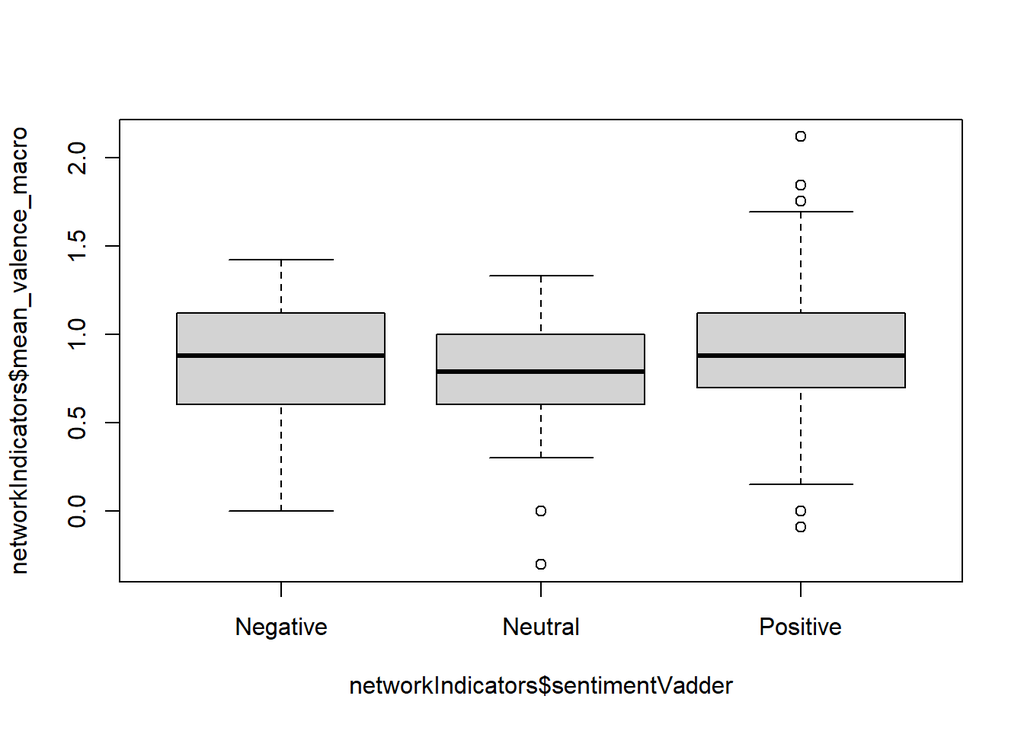

```r
networkIndicators$sentimentVadder <- sentimentAnalysis$sentimentVadder
networkIndicators$sentimentVadder <- as.factor(networkIndicators$sentimentVadder)
boxplot(networkIndicators$mean_valence_macro ~ networkIndicators$sentimentVadder)
```

```r
summary(aov(formula = networkIndicators$mean_valence_macro ~ networkIndicators$sentimentVadder))
```

```
                                   Df Sum Sq Mean Sq F value Pr(>F)
networkIndicators$sentimentVadder   2  0.618  0.3092   2.201  0.114
Residuals                         166 23.323  0.1405
```

## 5.2 Latent Dirichlet Allocation

a statistical model used primarily for topic modeling, which allows sets of observations to be explained by unobserved groups that explain why some parts of the data are similar

```r
articles_corpus_tdm <- tm::TermDocumentMatrix(questionnaire$openQuestion_Ethic[nchar(questionnaire$openQuestion_Ethic) >= 100],
                                   control =
                                     list(removePunctuation = TRUE,
                                          stopwords = stopwords::stopwords("de"),
                                          tolower = TRUE,
                                          stemming = FALSE,
                                          removeNumbers = TRUE,
                                          bounds = list(global = c(2, Inf)),
                                          wordLengths = c(3, 30))) # sensitive to keep only words with at least 3 characters
inspect(articles_corpus_tdm[1:10,])
```

```
<<TermDocumentMatrix (terms: 10, documents: 122)>>
Non-/sparse entries: 82/1138
Sparsity           : 93%
Maximal term length: 14
Weighting          : term frequency (tf)
Sample             :
                Docs
Terms            1 19 2 49 5 76 83 9 98 99
  beeinflussen   1  0 0  0 0  0  0 0  1  0
  beispiel       0  0 1  1 0  0  0 0  0  0
  deswegen       0  0 1  0 0  0  0 0  0  1
  falls          2  0 0  0 0  0  0 0  0  1
  materialsystem 0  0 1  0 1  0  0 0  0  0
  menschen       3  3 0  1 0  2  1 1  1  0
  nachhaltigen   0  0 1  0 0  0  0 0  0  0
  schädigen      1  0 0  0 0  0  0 0  0  0
  schlecht       1  0 0  0 0  0  0 0  0  0
  umwelt         2  0 0  1 1  2  2 1  1  1
```

```r
DTM <- as.DocumentTermMatrix(x = articles_corpus_tdm)

result_LDAtuning <- ldatuning::FindTopicsNumber(
  DTM,
  topics = seq(from = 2, to = 20, by = 1),
  metrics = c("CaoJuan2009",  "Deveaud2014"),
  method = "Gibbs",
  control = list(seed = 77),
  verbose = TRUE
)
```

```
fit models... done.
calculate metrics:
  CaoJuan2009... done.
  Deveaud2014... done.
```

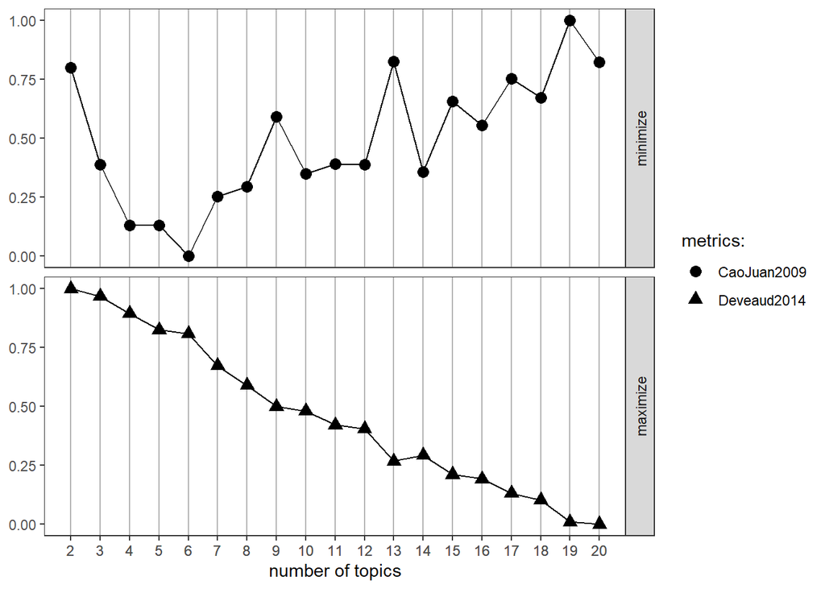

```r
ldatuning::FindTopicsNumber_plot(result_LDAtuning)
```

```r
# number of topics
K <- 6
# set random number generator seed
set.seed(111)
# compute the LDA model, inference via 1000 iterations of Gibbs sampling
topicModel <- topicmodels::LDA(x = DTM, k = K, method="Gibbs", control=list(iter = 500, verbose = 25))
```

```
K = 6; V = 273; M = 122
Sampling 500 iterations!
Iteration 25 ...
Iteration 50 ...
Iteration 75 ...
Iteration 100 ...
Iteration 125 ...
Iteration 150 ...
Iteration 175 ...
Iteration 200 ...
Iteration 225 ...
Iteration 250 ...
Iteration 275 ...
Iteration 300 ...
Iteration 325 ...
Iteration 350 ...
Iteration 375 ...
Iteration 400 ...
Iteration 425 ...
Iteration 450 ...
Iteration 475 ...
Iteration 500 ...
Gibbs sampling completed!
```

```r
terms(topicModel, 10)
```

```
      Topic 1    Topic 2          Topic 3         Topic 4
 [1,] "dass"     "leben"          "ethisch"       "umwelt"
 [2,] "menschen" "nachhaltigkeit" "relevant"      "materialien"
 [3,] "umwelt"   "material"       "ökologisch"    "moralisch"
 [4,] "mehr"     "weniger"        "technologien"  "klimawandel"
 [5,] "wichtig"  "wichtigsten"    "planeten"      "generationen"
 [6,] "unsere"   "bioinspiriert"  "eigenschaften" "viele"
 [7,] "schaden"  "besten"         "sollten"       "produkte"
 [8,] "sicht"    "beeinflussen"   "thema"         "geht"
 [9,] "sollten"  "fortschritt"    "falls"         "möglich"
[10,] "unseren"  "natürlich"      "nachhaltig"    "ähnlich"
      Topic 5           Topic 6
 [1,] "begriffe"        "wichtig"
 [2,] "zeit"            "umweltfreundlich"
 [3,] "nachhaltige"     "neue"
 [4,] "materialsystem"  "langlebig"
 [5,] "generationen"    "nachhaltig"
 [6,] "daher"           "energie"
 [7,] "handeln"         "materialsysteme"
 [8,] "zukunft"         "welt"
 [9,] "menschheit"      "müssen"
[10,] "umweltschädlich" "denke"
```

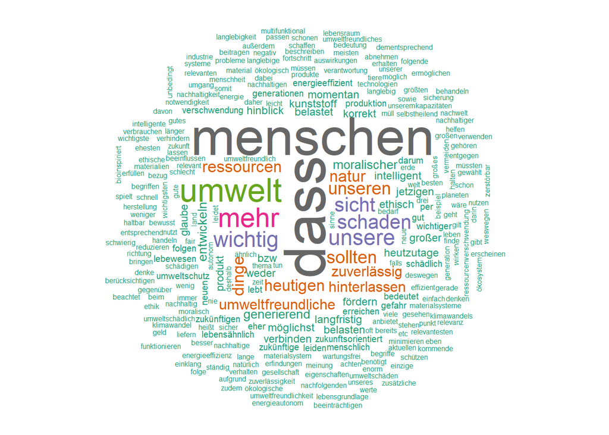

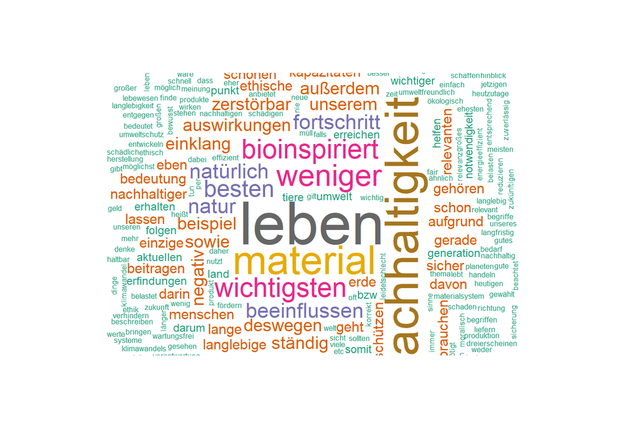

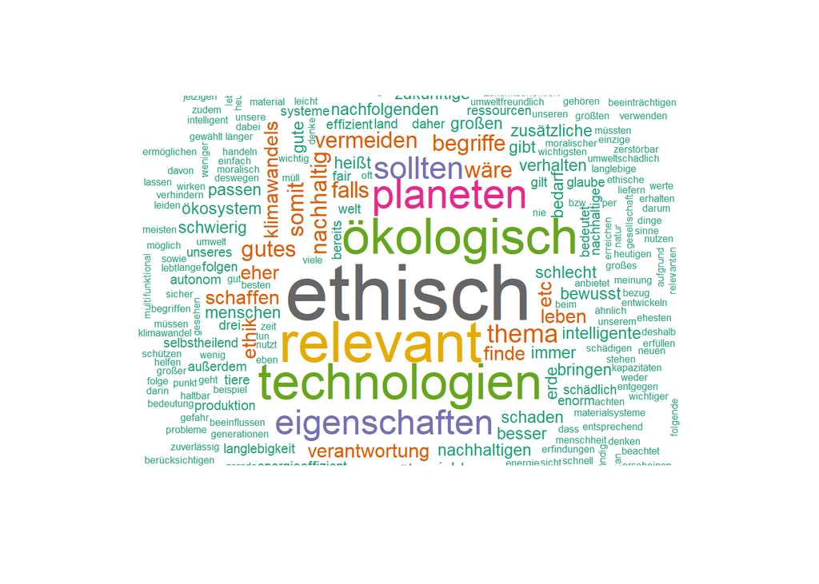

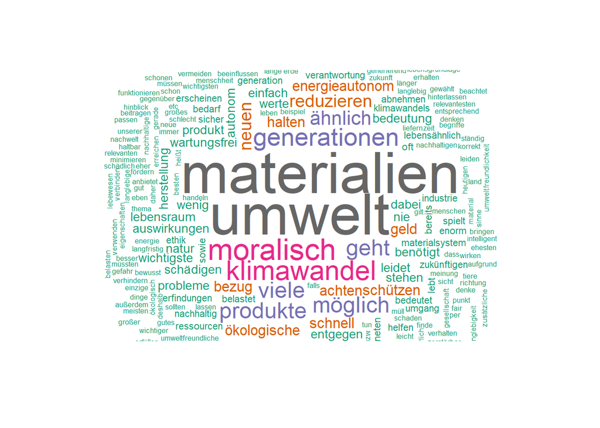

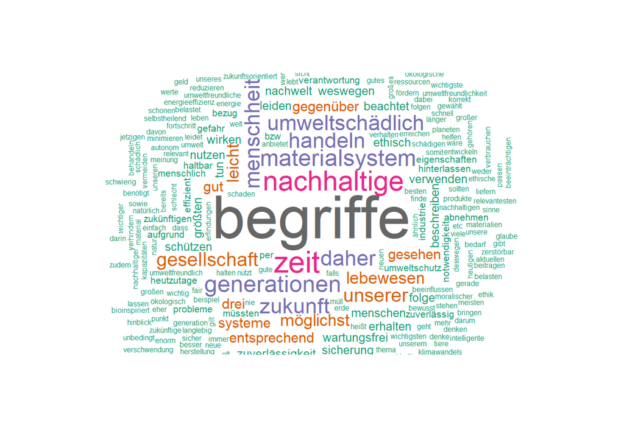

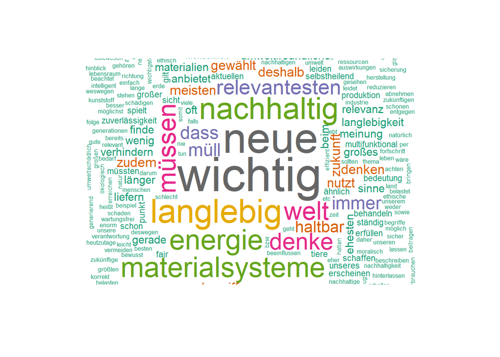

```r
for(i in 1:K){
  topic <- i
  df <- data.frame(term = topicModel@terms, p = exp(topicModel@beta[topic,]))
  head(df[order(-df$p),])

  mycolors <- RColorBrewer::brewer.pal(8, "Dark2")
  wordcloud::wordcloud(df$term, df$p, random.order = FALSE, color = mycolors, max.words = 300)
}
```

# 6 identify persons who talked about environment, nature

```r
tmp_dat <- questionnaire[, c("PROLIFIC_PID", "multipleEthic", "openQuestion_Ethic")]


### sort multipleEthic

for(i in 1:nrow(tmp_dat)){
  tmp <- unlist(str_split(string = tmp_dat$multipleEthic[i], pattern = "\\\\"))
  tmp <- str_trim(string = tmp, side = "both")
  tmp <- sort(tmp)

  tmp_dat$multipleEthic[i] <- paste0(tmp, collapse = " \\ ")
}


sort(table(tmp_dat$multipleEthic))
```

```
                                       aktive Formänderung durch Umwelteinwirkung \\ Insekten ähnlich \\ lebensähnlich
                                                                                                                     1
                                            aktive Verhaltensänderung durch Umwelteinwirkung \\ autonom \\ intelligent
                                                                                                                     1
                                   aktive Verhaltensänderung durch Umwelteinwirkung \\ lebensähnlich \\ reaktionsfähig
                                                                                                                     1
aktive Verhaltensänderung durch Umwelteinwirkung \\ passive Verhaltensänderung durch Umwelteinwirkung \\ selbstheilend
                                                                                                                     1
                                                                               autonom \\ elektronikfrei \\ ökologisch
                                                                                                                     1
                                                                          autonom \\ Energie generierend \\ nachhaltig
                                                                                                                     1
                                                                          autonom \\ Energie generierend \\ ökologisch
                                                                                                                     1
                                                                            autonom \\ Insekten ähnlich \\ intelligent
                                                                                                                     1
                                                                              autonom \\ Insekten ähnlich \\ langlebig
                                                                                                                     1
                                                                              autonom \\ langlebig \\ umweltfreundlich
                                                                                                                     1
                                                                            autonom \\ lebensähnlich \\ reaktionsfähig
                                                                                                                     1
                                                                             autonom \\ nachhaltig \\ umweltfreundlich
                                                                                                                     1
                                                                              autonom \\ ökologisch \\ umweltschädlich
                                                                                                                     1
                                                              bioinspiriert \\ Energie generierend \\ umweltfreundlich
                                                                                                                     1
                                                                 bioinspiriert \\ energieeffizient \\ umweltfreundlich
                                                                                                                     1
                                                               bioinspiriert \\ enthält Kunststoff \\ Insekten ähnlich
                                                                                                                     1
                                                                                bioinspiriert \\ haltbar \\ ökologisch
                                                                                                                     1
                                                                       bioinspiriert \\ lebensähnlich \\ selbstheilend
                                                                                                                     1
                                                                 bioinspiriert \\ leicht zerstörbar \\ multifunktional
                                                                                                                     1
                                                                            bioinspiriert \\ ökologisch \\ zuverlässig
                                                                                                                     1
```

[output cut: 139 more lines]

```
                                                                                                                     3
                                                                           nachhaltig \\ ökologisch \\ umweltschädlich
                                                                                                                     3
                                                                         nachhaltig \\ umweltfreundlich \\ zuverlässig
                                                                                                                     3
                                                                    energieeffizient \\ ökologisch \\ umweltfreundlich
                                                                                                                     5
                                                                     nachhaltig \\ umweltfreundlich \\ umweltschädlich
                                                                                                                     6
                                                                    energieeffizient \\ nachhaltig \\ umweltfreundlich
                                                                                                                    11
                                                                           langlebig \\ nachhaltig \\ umweltfreundlich
                                                                                                                    11
                                                                          nachhaltig \\ ökologisch \\ umweltfreundlich
                                                                                                                    22
```

```r
### get Boolean value is something related to nature / environment was mentioned
tmp_dat$boolean_ecology <- str_detect(string = tmp_dat$openQuestion_Ethic, pattern = "Umwelt|Nachhaltigkeit|nachhaltig|ökologisch|Klima|Ökosystem|umweltfreundlich|Natur")

table(tmp_dat$boolean_ecology) / nrow(tmp_dat)
```

```
    FALSE      TRUE
0.3254438 0.6745562
```

```r
tmp_dat$openQuestion_Ethic[tmp_dat$boolean_ecology == FALSE]
```

```
 [1] "autonome und inteligente lebensähnliche Eigenschaften klingen erstmal unmoralisch aus."
 [2] "Ich bin mir nicht sicher, ob es gut ist das es von selbst handeln und reagieren kann"
 [3] "Ich bin der Meinung, dass es wichtig ist, zukunftsorientiert zu agieren, wenn es um neue Erfindungen geht. Also etwas, dass wenig Schaden verursacht, lange nutzbar ist, und nach ende seines Lebenszyklus leicht abgearbeitet oder wiederverwertet werden kann."
 [4] "Die drei Begriffe haben für mich die größte Beziehung zur Ethik"
 [5] "In der heutigen Zeit ist es so wichtig wie nie neue Technologien zu Entwickeln die Nachhaltig sind. Dies sollte aus moralischer sicht an erster Stelle stehen. "
 [6] "In einer progressiven Gesellschaft, die nicht durch irgendwelche Halluzinationen oder Wahnvorstellungen offensichtliche Erkenntnisse leugnet, sind dies wichtige Maxime, an denen wir unseren Fortschritt als Menschheit orientieren sollten."
 [7] "Eine einfach zu verstehende Lösung die kaum Aufmerksamkeit benötigt ist natürlich am wichtigsten. Energie generieren wäre dabei noch optimal um andere umweltschädigende Alternativen zu minimieren."
 [8] "Gerade in der heutigen Zeit finde ich energieeffizienz und umweltvreundlichkeit sehr wichtig, sowie die Zuverlässigkeit von Systemen."
 [9] "die Verhaltensänderung war der Punkt wo ich überlegt habe, ob es okay ist, denn für manche ist ein Verhalten richtig, für andere wieder nicht, die Verhaltensänderung muss mit Richtlinien untermauert werden, denn es kann schnell auch in die Gesellschaftlich falsche Richtung laufen, wobei ich di…
[10] "haltbar und selbstheilend bedeutet weniger müll, kosteneffizienz und \nenergie generierend beudeutet man kann dem klimawandel entgegen wirken, indem man auf altmodische energiegewinnung verzichten könnte"
[11] "Von den Begriffen die gegeben sind denke ich das diese 3 am ehesten dafür geeignet sind. \nDer Rest der Begriffe ist denke ich nicht wirklich ethisch relevant."
[12] "Haltbar, da es ja ein Bau ist der den Menschen eine Zeit lang helfen soll und nicht nur einen Augenblick."
[13] "Alle drei Begriffe sind sowohl auf den Menschen auch auf Tiere anwendbar, sind wechselseitig und bedingen sich "
[14] "Konsumgesellschaft ist schädlich für unsere Erde. Wenn Leute nicht ständig neue Dinge kaufen müssten, i.e. wenn alte Dinge länger halten würden, wäre dies ein wichtiger Schritt in die richtige Richtung. Produkte aus dem 20. Jahrhundert waren qualitativ langlebiger als heutzutage, was anzeigt, …
[15] "Die Auswahl der ethisch relevanten Begriffe bezieht sich auf Eigenschaften, die nicht nur einem Invidiuum sondern der ganzen Gesellschaft verhelfen sollen."
```

[output cut: 40 more lines]

```r
setwd("outputs/02_analyses_text")
xlsx::write.xlsx2(x = tmp_dat, file = "ethicalRelevance.xlsx")
```